IIC-2233 Apunte Programación Avanzada  
© 2015 Karim Pichara - Christian Pieringer. Todos los derechos reservados.

# Funciones en Python

Existen muchas funciones que vienen implementadas en Python, principalmente con el propósito de simplificar y abstraer cálculos que pueden aplicar a muchos tipos de clases distintas (duck typing). Veamos algunos ejemplos:

# Len

Retorna el número de elementos en algún tipo de contenedor (lista, arreglo, set, etc)

```python
print(len([3,4,1,5,5,2]))
print(len({'nombre': 'Juan', 'apellido': 'Martinez'}))
print(len((4,6,2,5,6)))
```

```
6
2
5
```

Esta función viene implementada como un método interno **(__len__)** en la mayoría de las clases de python:

```python
print([3,4,1,5,5,2].__len__())
print({'nombre': 'Juan', 'apellido': 'Martinez'}.__len__())
```

```
6
2
```

La función len() aplicada a un objeto en particular MyObject hace efectivamente un llamado a la función MyObject.__len__()

```python
print(id([3,4,1,5,5,2].__len__()))
print(id(len([3,4,1,5,5,2])))
```

```
4297366656
4297366656
```

Podemos también hacer overriding del método. Supongamos que queremos implementar un tipo especial de lista cuyo método __len__ retorna el largo de la lista sin considerar los elementos que se repiten:

```python
from collections import defaultdict

class MyLista(list):
    def __len__(self):
        d = defaultdict(int)#cada vez que se llame con un key que no existe, se genera como defaul el valor 0, que sale de llamar
        #a "int" sin argumentos (probar tipeando int() en la consola de Python).
        for i in range(list.__len__(self)):#aquí llamamos a la función len de la clase list
            d.update({self[i] : d[self[i]] + 1})
        return len(d)#aquí se llama al método len de d, que es un defaultdict

L = MyLista([1,2,3,4,5,6,6,7,7,7,7,2,2,3,3,1,1])
print(len(L))
```

```
7
```

# **getitem**

Al definir esta función dentro de una clase, cada instancia de la clase pasa a ser un iterable (se puede iterar sobre la instancia, pronto profundizaremos más en lo que son los iterables).

```python
class MiClase:
    def __init__(self, palabra = None):
        self.palabra = palabra

    def __getitem__(self, i):
         return self.palabra[i]

p = MiClase("hola_mundo")
print(p[0])

[print(c) for c in p]

(a,b,c,d) = p[0:4]
print(a,b,c,d)
print(list(p))
print(tuple(p))
```

```
h
h
o
l
a
_
m
u
n
d
o
h o l a
['h', 'o', 'l', 'a', '_', 'm', 'u', 'n', 'd', 'o']
('h', 'o', 'l', 'a', '_', 'm', 'u', 'n', 'd', 'o')
```

# Reversed

La función reversed() toma una sequencia cualquiera como input y retorna una copia de la secuencia en orden inverso. También podemos personalizar la función haciendo un overriding de __reversed__ en cada clase. Si no personalizamos el método __reversed__, simplemente se usará el built-in, que iterará usando __getitem__ y __len__ (itera __len__ veces sobre el objeto usando __getitem__, hacia atrás)

```python
lista = [1,2,3,4,5,6]

class MiSecuencia():
    #Como en esta clase no estamos haciendo overriding del método __reversed__, simplemente se
    #usará el built-in, que iterará usando __getitem__ y __len__
    def __len__(self):
        return 9

    def __getitem__(self, index):
        return "Item_{0}".format(index)

class MiReversa(MiSecuencia):
    def __reversed__(self):
        return "Reversando!!"

for seq in lista, MiSecuencia(), MiReversa():
    print("\n{} : ".format(seq.__class__.__name__), end = "")
    for item in reversed(seq):
        print(item, end = ", ")
```

```
list : 6, 5, 4, 3, 2, 1,
MiSecuencia : Item_8, Item_7, Item_6, Item_5, Item_4, Item_3, Item_2, Item_1, Item_0,
MiReversa : R, e, v, e, r, s, a, n, d, o, !, !,
```

# Enumerate

enumerate() crea una lista de tuplas donde el primer objeto en cada tupla es el indice y el segundo es el item original:

```python
lista = ["a","b","c","d"]

for i,j in enumerate(lista):
    print("{}: {}".format(i,j))

print([par for par in enumerate(lista)])

print({i:j for i, j in enumerate(lista)})#aquí creamos un diccionario con el indice entregado por enumerate usado como key
```

```
0: a
1: b
2: c
3: d
[(0, 'a'), (1, 'b'), (2, 'c'), (3, 'd')]
{0: 'a', 1: 'b', 2: 'c', 3: 'd'}
```

# Zip

Toma dos o más secuencias y genera una secuencia de tuplas.

```python
variables = ['nombre', 'apellido', 'email']
p1 = ["Juan", 'Perez', 'jp1@hotmail.com']
p2 = ["Gonzalo", 'Aldunate', 'gan@gmail.com']
p3 = ["Alberto", 'Gomez', 'agomez@yahoo.com']

contactos = []
for p in p1,p2,p3:
    contacto = zip(variables, p)
    contactos.append(dict(contacto))

for c in contactos:
    print("Nombre: {nombre} {apellido}, email: {email}".format(**c))#el doble asterisco es para pasar el diccionario c como "keyworded" argumentos
    #es equivalente a .format(nombre = c["nombre"], apellido = c["apellido"], email = c["email"]
```

```
Nombre: Juan Perez, email: jp1@hotmail.com
Nombre: Gonzalo Aldunate, email: gan@gmail.com
Nombre: Alberto Gomez, email: agomez@yahoo.com
```

### La función zip() también es la inversa de sí misma:

```python
A = [1, 2, 3, 4]
B = ['a', 'b', 'c', 'd']

zipped = zip(A,B)
zipped = list(zipped)
print(zipped)
unzipped = zip(*zipped)
unzipped = list(unzipped)
print(unzipped)
```

```
[(1, 'a'), (2, 'b'), (3, 'c'), (4, 'd')]
[(1, 2, 3, 4), ('a', 'b', 'c', 'd')]
```

# Comprehensions

```python
lista = ['1', '4', '55', '65','4', '15', '90']
int_lista = [int(c) for c in lista]
print(int_lista)

int_lista_2d = [int(c) for c in lista if len(c) > 1]
print(int_lista_2d)
```

```
[1, 4, 55, 65, 4, 15, 90]
[55, 65, 15, 90]
```

```python
secuencia = ["one", "two", "three"]

s2 = ['%d: %s' % (i,j) for i,j in enumerate(secuencia)]#estilo antiguo de formateo del print

print(s2)
```

```
['0: one', '1: two', '2: three']
```

# Comprensión de Sets y Diccionarios

```python
from collections import namedtuple
#namedtuple es una subclase de tuplas que tiene campos (con nombres arbitrarios), pueden ser accesados como tupla.campo
Pelicula = namedtuple("Pelicula", ["titulo", "director", "genero"])
peliculas = [Pelicula("Into the Woods", "Rob Marshall", "Adventure"),
           Pelicula("American Sniper", "Clint Eastwood", "Action"),
           Pelicula("Birdman", "Alejandro González Inárritu", "Comedy"),
           Pelicula("Boyhood", "Richard Linklater", "Drama"),
           Pelicula("Taken 3", "Olivier Megaton", "Action"),
           Pelicula("The Imitation Game", "Morten Tyldum", "Biography"),
           Pelicula("Gone Girl", "David Fincher", "Drama")]

directores_accion = {b.director for b in peliculas if b.genero == 'Action'}#set comprehension
print(directores_accion)
```

```
{'Clint Eastwood', 'Olivier Megaton'}
```

### Podemos crear diccionarios con los resultados de búsqueda:

```python
dict_directores_accion = {b.director: b for b in peliculas if b.genero == 'Action'}
print(dict_directores_accion)
```

```
{'Clint Eastwood': Pelicula(titulo='American Sniper', director='Clint Eastwood', genero='Action'), 'Olivier Megaton': Pelicula(titulo='Taken 3', director='Olivier Megaton', genero='Action')}
```

```python
dict_directores_accion['Olivier Megaton']
```

```
Pelicula(titulo='Taken 3', director='Olivier Megaton', genero='Action')
```

# Iterables e Iteradores

Un **iterable** es cualquier objeto sobre el cual se puede iterar, por lo mismo, cualquier iterable podría aparecer al lado derecho de un for loop ( for i in iterable: ). Un iterable contiene el método **iter**(). Se puede iterar todas las veces que uno quiera sobre un iterable, como en el caso de las listas por ejemplo.

Un **iterador** es un objeto que itera sobre un iterable, es el objeto retornado por el método **iter**(), además contiene el método **next**() que nos va retornando el siguiente elemento.

```python
x = [11, 32, 43]
for c in x: print(c)
print(x.__iter__)
next(x)#aqui podemos ver que una lista no es un iterador
```

```
11
32
43
<method-wrapper '__iter__' of list object at 0x104c2a188>
```

```
---------------------------------------------------------------------------
TypeError                                 Traceback (most recent call last)
<ipython-input-183-12f0c2472895> in <module>()
      2 for c in x: print(c)
      3 print(x.__iter__)
----> 4 next(x)#aqui podemos ver que una lista no es un iterador

TypeError: 'list' object is not an iterator
```

Como vemos arriba, las listas no son un iterador, pero podemos obtener un iterador sobre una lista simplemente llamando al método iter()

```python
y = iter(x)
print(next(y))
print(next(y))
print(next(y))
```

```
11
32
43
```

```python
class Carta():
    MONOS = {11: 'J', 12: 'Q', 13: 'K'}
    def __init__(self, numero, pinta):
        self.pinta = pinta
        self.numero = numero if numero <=10 else Carta.MONOS[numero]
    def __str__(self):
        return "%s %s" % (self.numero, self.pinta)

class Baraja():
    def __init__(self):
        self.cartas = []
        for p in ['Espada', 'Diamante', 'Corazon', 'Trebol']:
            for n in range(1, 14):
                self.cartas.append(Carta(n, p))
```

```python
for c in Baraja().cartas: print(c)
```

```
1 Espada
2 Espada
3 Espada
4 Espada
5 Espada
6 Espada
7 Espada
8 Espada
9 Espada
10 Espada
J Espada
Q Espada
K Espada
1 Diamante
2 Diamante
```

[output cut: 37 more lines]

Si bien la clase Baraja() contiene muchas cartas, no podemos iterar sobre Baraja(), sólo sobre Baraja().cartas (que corresponde a una lista, por lo tanto es iterable). Supongamos que queremos iterar sobre Baraja() directamente, para ello deberíamos agregar el método **iter**

```python
class Baraja():
    def __init__(self):
        self.cartas = []
        for p in ['Espada', 'Diamante', 'Corazon', 'Trebol']:
            for n in range(1, 14):
                self.cartas.append(Carta(n, p))
    def __iter__(self):
        return iter(self.cartas)
```

```python
for c in Baraja(): print(c)
```

```
1 Espada
2 Espada
3 Espada
4 Espada
5 Espada
6 Espada
7 Espada
8 Espada
9 Espada
10 Espada
J Espada
Q Espada
K Espada
1 Diamante
2 Diamante
```

[output cut: 37 more lines]

Veamos un ejemplo de cómo crear un iterador (debe contener los métodos **iter** y **next**)

```python
class Fib:
    def __init__(self):
        self.prev = 0
        self.actual = 1

    def __iter__(self):
        return self

    def __next__(self):
        valor = self.actual
        self.actual += self.prev
        self.prev = valor
        return valor
```

```python
f = Fib()
N = 10
l = [next(f) for i in range(N)]
print(l)
```

```
[1, 1, 2, 3, 5, 8, 13, 21, 34, 55]
```

El módulo "itertools" de Python provee varios iteradores:

```python
import itertools

letras = ['a', 'b', 'c', 'd', 'e', 'f']
bools = [1, 0, 1, 0, 0, 1]
nums = [23, 20, 44, 32, 7, 12]
decimales = [0.1, 0.7, 0.4, 0.4, 0.5]

colors = itertools.cycle(letras)
print(next(colors))
print(next(colors))
print(next(colors))
print(next(colors))
print(next(colors))
print(next(colors))
print(next(colors))
print(next(colors))
print(next(colors))
print(next(colors))

for i in itertools.chain(letras, bools, decimales): print(i, end=" ")
print()
for i in  itertools.compress(letras, bools): print(i, end=" ")
```

```
a
b
c
d
e
f
a
b
c
d
a b c d e f 1 0 1 0 0 1 0.1 0.7 0.4 0.4 0.5
a c f
```

# Generadores

Los generadores son un caso especial de los iteradores. Los generadores nos permiten iterar sobre secuencias de datos sin la necesidad de almacenarlos en alguna estructura de datos, evitando el uso innecesario de memoria. Una vez que terminamos de iterar sobre un generador, el generador desaparece. Esto es muy útil cuando queremos realizar cálculos sobre secuencias de números que sólo nos sirven para ese cálculo en particular. La sintaxis para crear generadores es muy parecida a la comprensión de listas, sólo que en vez de paréntesis cuadrados [] usamos paréntesis normales ():

```python
from sys import getsizeof
a = (b for b in range(10))#por el sólo hecho de usar paréntesis significa que estamos creando un generador
#print(sum(a))
print(getsizeof(a))
c = [b for b in range(10)]#c usa más memoria que a
print(getsizeof(c))
for b in a: print(b)
print(sum(a))#como ya terminamos de iterar sobre a, la secuencia desaparece
```

```
72
192
0
1
2
3
4
5
6
7
8
9
0
```

## Ejemplo:

Procesamiento de un archivo Supongamos este contenido para el archivo logs.txt:

Abr 13, 2014 09:22:34

Jun 14, 2014 08:32:11

May 20, 2014 10:12:54

Dic 21, 2014 11:11:62

WARNING Estamos cercanos a tener un problema.

WARNING Otro warning!

WARNING Casi un bug

WARNING Tenga mucho cuidado

```python
import sys
inname, outname = "logs.txt", "logs_out.txt"
with open(inname) as infile:
    with open(outname, "w") as outfile:
        warnings = (l.replace('WARNING', '') for l in infile if 'WARNING' in l)
        for l in warnings:
            outfile.write(l)
```

## Este sería el output:

Estamos cercanos a tener un problema.

Otro warning!

Casi un bug

Tenga mucho cuidado

## Funciones Generadoras

Las funciones en Python también tienen la posibilidad de funcionar como generadores, a través de "yield". El statement "yield" reemplaza a "return", por un lado se encarga de retornar el valor pero además nos asegura que en la próxima llamada a la función, ésta será ejecutada partiendo desde el punto donde quedó en la ejecución anterior, en otras palabras, trabajamos con una función que una vez que "retorna" un valor a través de "yield", está transfierendo el control sólo en forma temporal, asumiendo que pronto será utilizada nuevamente para "generar" más valores. Al llamar a una función generadora se crea un objeto generador, sin embargo, esto no comienza a ejecutar la función. Ejemplo:

```python
def conteo_dec(n):
    print("Contando en forma decreciente desde {}".format(n))
    while n > 0:
        yield n
        n -= 1
```

La función se ejecuta una vez que llamamos a next del objeto generado por la función (la función retorna un generador)

```python
x = conteo_dec(10)#notar que aquí no se imprime nada
print("{}\n".format(x))#aquí sólo se imprime el objeto
y = conteo_dec(5)
print(next(y))
print(next(y))
print(next(y))
print(next(y))
#for i in conteo_dec(5):
#    print(i)
```

```
<generator object conteo_dec at 0x10506ae10>

Contando en forma decreciente desde 5
5
4
3
2
```

```python
def fibonacci():
    a,b = 0,1
    while True:
        yield b
        a, b = b, a + b

f = fibonacci()
print(next(f))
print(next(f))
print(next(f))
print(next(f))
print(next(f))
print(next(f))
g1 = [next(f) for i in range(10)]
print(g1)
g2 = (next(f) for i in range(10))
for a in g2: print(a)
```

```
1
1
2
3
5
8
[13, 21, 34, 55, 89, 144, 233, 377, 610, 987]
1597
2584
4181
6765
10946
17711
28657
46368
75025
121393
```

```python
import numpy as np
def maximo(values):
    temp_maxim = -np.infty
    for v in values:
        if v > temp_maxim:
            temp_maxim = v
        yield temp_maxim

elements = [10, 14, 7, 9, 12, 19, 33]
res = maximo(elements)
print(next(res))
print(next(res))
print(next(res))
print(next(res))
print(next(res))
print(next(res))
print(next(res))
print(next(res))#aquí se acabó la lista
```

```
10
14
14
14
14
19
33
```

```
---------------------------------------------------------------------------
StopIteration                             Traceback (most recent call last)
<ipython-input-51-74f567459f64> in <module>()
     16 print(next(res))
     17 print(next(res))
---> 18 print(next(res))#aquí se acabó la lista

StopIteration:
```

### También podemos interactuar con la función enviando mensajes

El método send() permite enviar un valor hacia el generador, lo que significa que la expresión "yield" lo recibirá. El valor enviado puede ser usado para asignarlo a otra variable, por ejemplo: v = yield self.value

```python
def mov_avg():
    total = float((yield))
    cont = 1
    while True:
        i = yield total / cont
        cont += 1
        total += i
```

Notar que el código debe ejecutar al menos hasta el primer "yield" para poder empezar a aceptar valores desde send(). Así siempre es necesario llamar a next() (o send(None)) una vez después de haber creado el generador para poder comenzar a enviarle datos.

```python
m = mov_avg()
print(next(m))
print(m.send(10))
print(m.send(5))
print(m.send(0))
print(m.send(0))
```

```
None
10.0
7.5
5.0
3.75
```

```python
def grep(pattern):#hace lo mismo que la función grep de la consola de Unix
    print("Buscando a %s" % pattern)
    while True:
        line = (yield)
        if pattern in line:
            print(line)

o = grep("Hola")#creo el objeto, no se ejecuta aún la función
next(o)#avanzo al primer yield, aquí se imprime "Buscando a ...."
o.send("Esta linea contiene Hola")
o.send("Esta linea no va a salir")
o.send("Esta linea si va a salir (porque contiene Hola :) )")
o.send("Esta linea tampoco va a salir")
```

```
Buscando a Hola
Esta linea contiene Hola
Esta linea si va a salir (porque contiene Hola :) )
```

# Lambda Functions

Las funciones lambda son pequeñas funciones creadas "on the fly", contienen expresiones que siempre son retornadas (no necesitan el statement "return"). Ejemplos:

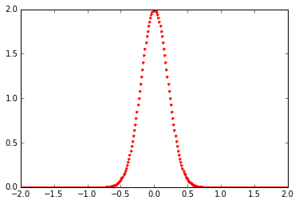

```python
import numpy as np
from matplotlib import pyplot as plt
#para que el gráfico se genere dentro del notebook y no en una ventana aparte
%matplotlib inline
Gauss = lambda x, mu, sigma : (1./(np.sqrt(2*np.pi)*sigma)) * np.exp(-0.5*((x - mu)/sigma)**2)

mu = 0.
sigma = 0.2
x = np.linspace(-2,2,300)
plt.plot(x, Gauss(x, mu, sigma), '.r')
plt.show()
```

# MAP

map recibe como parámetros una función y un iterable, retorna un generador que resulta de aplicar de la función sobre el iterable. map(f, iterable) es equivalente a [f(x) for x in iterable]

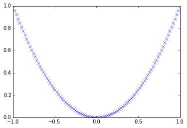

```python
pow2 = lambda x : x**2
t = np.linspace(-1.,1., 100)#crea un arreglo numpy de 100 elementos, partiendo desde -1 y llegando a 1
plt.plot(t, list(map(pow2, t)), 'xb')
plt.show()
```

Map puede ser aplicado también en más de una lista:

```python
a = [1,2,3,4]
b = [17,12,11,10]
c = [-1,-4,5,9]

c1 = list(map(lambda x,y : x+y, a,b))

c2 = list(map(lambda x,y,z : x+y+z, a,b,c))

c3 = list(map(lambda x,y,z : 2.5*x + 2*y - z, a,b,c))

print(c1)
print(c2)
print(c3)
```

```
[18, 14, 14, 14]
[17, 10, 19, 23]
[37.5, 33.0, 24.5, 21.0]
```

# Filter

filter(f, secuencia) retorna el resultado de aplicar la función f a la secuencia dejando afuera los datos en que el resultado fue False, por lo mismo, la función f debe retornar un valor booleano.

```python
f = fibonacci() #función definida más arriba
fib = [next(f) for i in range(11)]
impares = list(filter(lambda x: x % 2 != 0, fib))
print(impares)

pares = list(filter(lambda x: x % 2 == 0, fib))
print(pares)
```

```
[1, 1, 3, 5, 13, 21, 55, 89]
[2, 8, 34]
```

# Reduce

reduce(f, [s1,s2,s3,...,sn]) retorna lo que resulta de aplicar la función f a la secuencia [s1,s2,s3,...,sn] de la siguiente forma: f(f(f(f(s1,s2),s3),s4),s5),...

[figure not shown]

```python
from functools import reduce
reduce(lambda x, y: x+y, range(1,10))
```

```
45
```

```python
import datetime
#Ej: computar el largo de la linea más larga en un archivo
#rstrip retorna una copia del string que resulta de eliminar los espacios (u otro caracter deseado)
#del final del string. Ej:  "Hola...".rstrip(".") retorna "Hola"

t = datetime.datetime.now()
r1 = reduce(max, map(lambda l : len(l.rstrip()), [line for line in open('logs_out.txt')]))
print("reduce time: {}".format(datetime.datetime.now() - t))
print(r1)

#version con comprensión de generadores y numpy
t = datetime.datetime.now()
r2 = max((len(line.rstrip()) for line in open('logs_out.txt')))
print("max(generator) time: {}".format(datetime.datetime.now() - t))
print(r2)

#para visualizar las lineas del archivo
for line in open('logs_out.txt'):
    print(line)
```

```
reduce time: 0:00:00.000984
38
max(generator) time: 0:00:00.000560
38
 Estamos cercanos a tener un problema.

 Otro warning!

 Casi un bug

 Tenga mucho cuidado
```

# Decoradores

Antes de definir lo que es un decorador, veamos algunas de las cosas que podemos hacer con las funciones en Python:

En Python uno puede asignar una función a una variable y luego usar esa variable igual que la función:

```python
def func_hola(nombre):
    return "Hola "+ nombre

saludar = func_hola
print(saludar("Juan"))
```

```
Hola Juan
```

También podemos definir funciones adentro de otras funciones:

```python
def func_hola(nombre):
    def get_mensage():
        return "Hola "

    res = get_mensage() + nombre
    return res

print(func_hola("Pedro"))
```

```
Hola Pedro
```

Las funciones también pueden ser pasadas como argumentos a otras funciones:

```python
def func_hola(nombre):
   return "Hola " + nombre

def llamar_func(func):
    otro_nombre = "Diego"
    return func(otro_nombre)

print(llamar_func(func_hola))
```

```
Hola Diego
```

Las funciones pueden retornar otras funciones:

```python
def compone_func_saludar():
    def get_mensage():
        return "Hola a todos!!"

    return get_mensage

saludar = compone_func_saludar()
print(saludar())
```

```
Hola a todos!!
```

Las funciones internas tienen acceso (sólo de lectura) a las variables (y argumentos) del scope de la función que la contiene:

```python
def compone_func_saludar(nombre):
    def get_mensage():
        return "Saludos para tí "+ nombre + "!"
    return get_mensage

saludar = compone_func_saludar("Ana")
print(saludar())
```

```
Saludos para tí Ana!
```

Ahora el mismo ejemplo pero con algunos prints que nos aclaran lo que ocurre cuando intentamos modificar una variable de la función que está un nivel más arriba:

```python
def compone_func_saludar(nombre):
    aux = 2
    print(id(aux))
    print(aux)
    def get_mensage():
        print("Entrando a get_mensaje()...")
        aux = 3
        print(id(aux))
        print(aux)
        return "Saludos para tí "+ nombre + "!"
    print(id(aux))
    print(aux)
    return get_mensage#en esta llamada se entra en la ejecución de get_mensaje

saludar = compone_func_saludar("Ana")
print(saludar())
```

```
4297366528
2
4297366528
2
Entrando a get_mensaje()...
4297366560
3
Saludos para tí Ana!
```

# Decoradores

Los decoradores nos permiten tomar una función ya implementada, agregar algún comportamiento o datos adicionales y retornar una nueva función. Podemos ver los decoradores simplemente como funciones que reciben una función f1 cualquiera retornan una función f2 distinta, por ejemplo si nuestro decorador se llama dec_1, para obtener la función modificada que queremos y asignarla a la misma función actual, simplemente escribimos f1 = dec_1(f1).

Con esto nuestra función f1 ahora queda con los nuevos datos y comportamiento agregados. Uno de los beneficios de los decoradores es que nos evitan la necesidad de modificar el código de la función original (así si queremos volver a la versión original de la función, simplemente quitamos el llamado al decorador). También nos evita crear una función distinta con otro nombre (esto sería un problema ya que habría que modificar todos los llamados a la función que queremos cambiar para que llamen a la función nueva).

Ej: Supongamos que tenemos la siguiente implementación recursiva ineficiente de la función que retorna los números Fibonacci:

```python
import datetime

def fib(n):
    if n == 0:
        return 0
    elif n == 1:
        return 1
    else:
        return fib(n-1) + fib(n-2)

n = 35
t1 = datetime.datetime.now()
print(fib(n))
print("Tiempo de ejecución: {}".format(datetime.datetime.now()-t1))
```

```
9227465
Tiempo de ejecución: 0:00:05.863439
```

Una implementación mucho más eficiente podría preocuparse de "memorizar" los números ya calculados en la secuencia de Fibonacci. Podemos usar un decorador que tome la función fib y le agregue una memoria y un chequeo que se preocupe de ver la existencia del número en algún cálculo anterior:

```python
def eficient_fib(f):#recibe una función como argumento
    data = {}
    def func(x):#aquí se crea la función nueva que será retornada
        if x not in data:
            data[x] = f(x)#aquí usa la función que recibió como argumento
        return data[x]
    return func

fib = eficient_fib(fib) #aquí aplicamos el decorador, la función fib queda "decorada" por la función "eficient_fib"
t1 = datetime.datetime.now()

print(fib(n)) #aquí vemos que seguimos usando el mismo nombre para la función, sin la necesidad de llamar a la función nueva
print("Tiempo de ejecución: {}".format(datetime.datetime.now()-t1))
```

```
9227465
Tiempo de ejecución: 0:00:00.000139
```

### Usando la notación alternativa para decoradores:

```python
@eficient_fib
def fib(n):
    if n == 0:
        return 0
    elif n == 1:
        return 1
    else:
        return fib(n-1) + fib(n-2)

n = 35
t1 = datetime.datetime.now()
print(fib(n))
print("Tiempo de ejecución: {}".format(datetime.datetime.now()-t1))
```

```
9227465
Tiempo de ejecución: 0:00:00.000174
```

### Podemos usar una jerarquía de decoradores y recibir parámetros para la decoración. Una forma genérica de hacerlo es la siguiente:

```python
def mydecorator(function):
    def _mydecorator(*args, **kw):
        # hacer algo aquí antes de aplicar la función
        # llamar a la función
        res = function(*args, **kw)
        # hacer algo después
        return res
    # retorna la sub función
    return _mydecorator
```

```python
import time
import hashlib
import pickle
from itertools import chain
cache = {}
def is_obsolete(entry, duration):
    return time.time() - entry['time']> duration

def compute_key(function, args, kw):
    key = pickle.dumps((function.__name__, args, kw))#retorna la representación en pickle del objeto como un objeto de bytes
                                                     #en vez de escribirlo a un archivo.
    return hashlib.sha1(key).hexdigest()#crea una key a partir del "frozen" key generado en el paso anterior

def memoize(duration=10):
    def _memoize(function):
        def __memoize(*args, **kw):
            key = compute_key(function, args, kw)

            #¿ya lo tenemos en cache?
            if (key in cache and not is_obsolete(cache[key], duration)):
                print('lo teníamos disponible')
                return cache[key]['value']

            # si no lo teníamos en cache
            print('calculando...')
            result = function(*args, **kw)
            # storing the result
            cache[key] = {'value': result,'time': time.time()}
            return result
        return __memoize
    return _memoize
```

```python
@memoize(0.0001)#esto es lo mismo a decir: complex_process = memoize(0.0001), que retorna una función (_memoize),
                #
def complex_process(a, b):
    return a + b

print(complex_process(2, 2))
print(complex_process(2, 1))
print(complex_process(2, 2))
print(complex_process(2, 2))
print(complex_process(2, 2))
print(complex_process(2, 2))
print(complex_process(2, 2))
print(complex_process(2, 2))
print(complex_process(2, 2))
```

```
calculando...
4
calculando...
3
calculando...
4
lo teníamos disponible
4
calculando...
4
lo teníamos disponible
4
calculando...
4
lo teníamos disponible
4
calculando...
4
```

# Ej: Decorador para proteger acceso

```python
class User(object):
    def __init__(self, roles):
        self.roles = roles

class Unauthorized(Exception):
     pass

def protect(role):
    def _protect(function):
        def __protect(*args, **kw):
            user = globals().get('user')
            if user is None or role not in user.roles:
                raise Unauthorized("No te voy a decir!!")#exceptions coming soon!
            return function(*args, **kw)
        return __protect
    return _protect
```

```python
juan = User(('admin', 'user'))
pedro = User(('user',))

class Secreto(object):
    @protect('admin')
    def receta_pisco_sour(self):
        print('usa mucho pisco!')

s = Secreto()
user = juan
s.receta_pisco_sour()
user = pedro
s.receta_pisco_sour()
```

```
usa mucho pisco!
```

```
---------------------------------------------------------------------------
Unauthorized                              Traceback (most recent call last)
<ipython-input-43-fd5dfc7ee51e> in <module>()
     11 s.receta_pisco_sour()
     12 user = pedro
---> 13 s.receta_pisco_sour()

<ipython-input-42-42bd9197b7d8> in __protect(*args, **kw)
     11             user = globals().get('user')
     12             if user is None or role not in user.roles:
---> 13                 raise Unauthorized("No te voy a decir!!")#exceptions coming soon!
     14             return function(*args, **kw)
     15         return __protect

Unauthorized: No te voy a decir!!
```